# Discrimination and Classification Agreement of Protein S100B and the WFNS Score in Aneurysmal Subarachnoid Hemorrhage

Abderrezzaq KADOUCHE

## **Introduction**

Aneurysmal subarachnoid hemorrhage (aSAH) is a severe neurological emergency associated with high morbidity and mortality, and early identification of patients likely to experience a poor neurological outcome remains a central challenge in neurocritical care.

Beyond its immediate clinical impact, aSAH generates substantial costs for healthcare systems due to prolonged intensive care stays, neurosurgical interventions, and long-term rehabilitation.

## **Objective**

- The primary objective of this study is to evaluate the discriminative performance of the S100B protein for predicting poor neurological outcome after aneurysmal subarachnoid hemorrhage, using a ROC curve and its area under the curve (AUC).
- The secondary objective is to assess the agreement between two binary classification rules : S100B dichotomized at its optimal threshold and WFNS dichotomized at ≥ 3 using Cohen’s kappa.

## **Study Design and Data**

This study is a retrospective analysis.

The dataset originates from the work of Turck et al. (2010), published in Intensive Care Medicine, and was originally designed to develop a multiparameter panel for outcome prediction following aneurysmal subarachnoid hemorrhage.

The analytical sample comprises 113 patients with confirmed aSAH, each described by seven variables (detailed in the next section).

## **Variable Specifications**

- `gos` : Glasgow Outcome Scale at follow-up: 1 (death), 2 (vegetative state), 3 (severe disability), 4 (moderate disability), 5 (good recovery).
- `outcome` : Dichotomized neurological outcome, used as the reference standard: Good (GOS 4–5), Poor (GOS 1–3).
- `gender` : Patient sex: Male, Female.
- `age` : Patient age at admission, in years.
- `wfns` : World Federation of Neurosurgical Societies grade reflecting clinical severity at admission: 1, 2, 3, 4, 5.
- `s100b` : Serum S100B protein concentration, a biomarker of brain injury.
- `ndka` : Serum neuron-specific enolase (NDKA) concentration, a biomarker of neuronal injury

## **Descriptive Analysis of Continuous Variables**

```r
library(prettyR)

vars_quanti <- c("age", "s100b", "ndka")

describe(
aSAH[, vars_quanti],
num.desc = c("min", "max", "mean", "median", "sd", "valid.n")
)
```

```
## Description of aSAH[, vars_quanti]
```

```
##
##  Numeric
##         min    max  mean median    sd valid.n
## age   18.00  81.00 51.10  51.00 13.87     113
## s100b  0.03   2.07  0.25   0.14  0.27     113
## ndka   3.01 419.19 19.66  12.22 40.22     113
```

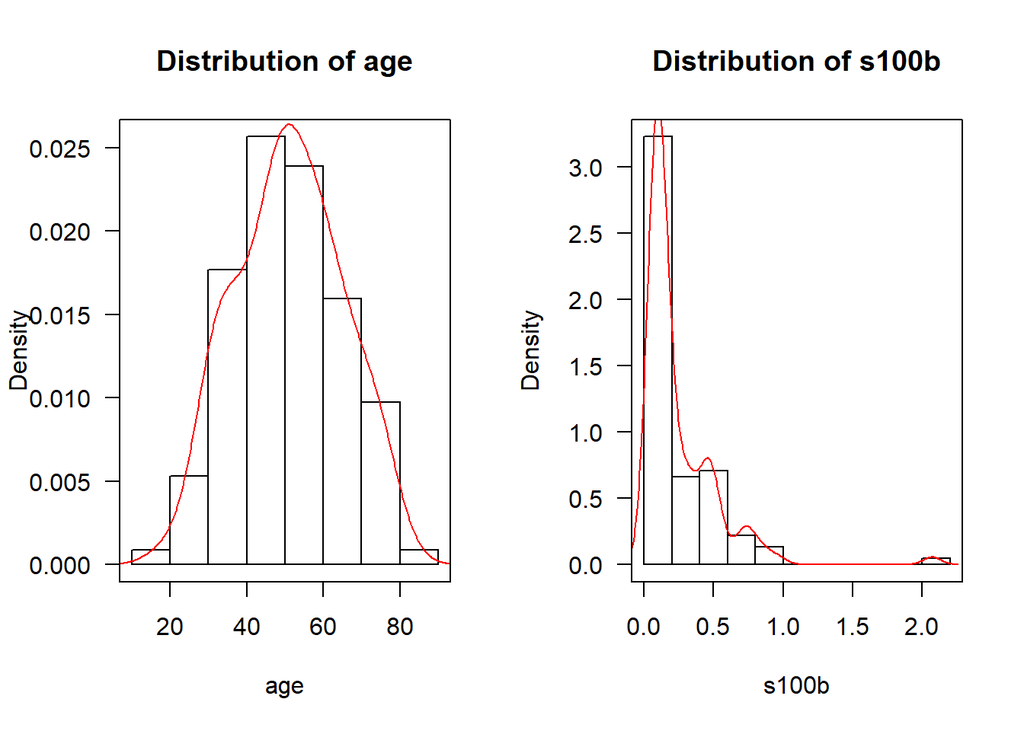

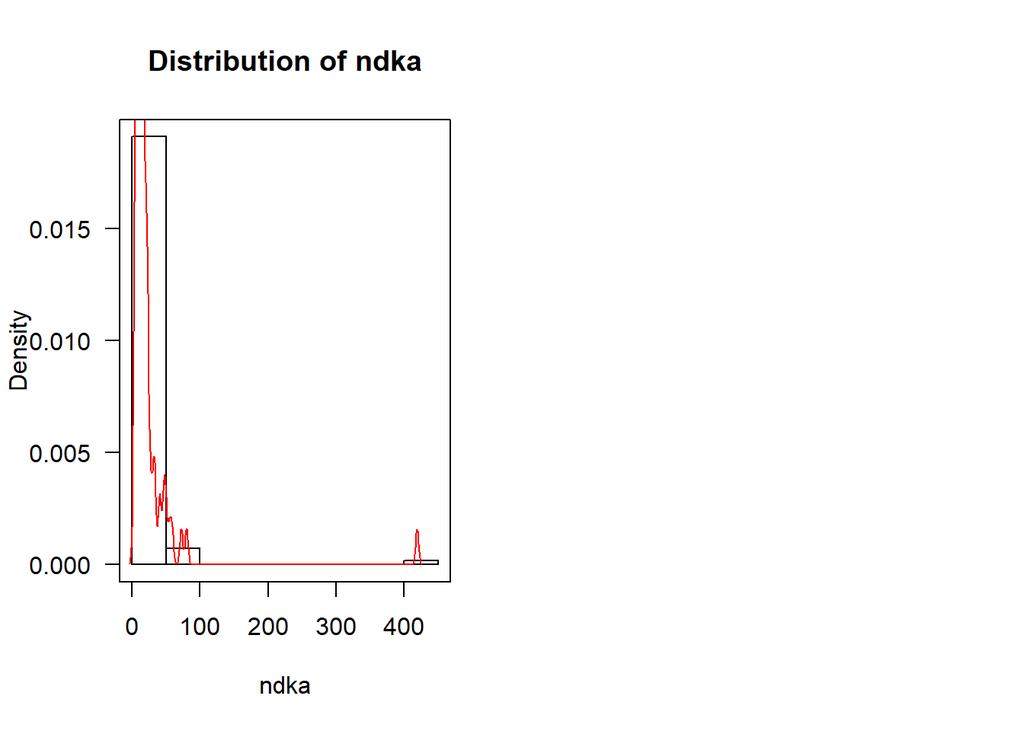

```r
par(mfrow = c(1, 2))
# Boucle sur toutes les variables quantitatives avec courbe de densité

for (var in vars_quanti) {
# 1. Tracer l'histogramme en mode "densité de probabilité" (prob = TRUE)
hist(aSAH[[var]],
main = paste("Distribution of", var), # Titre dynamique
xlab = var,                           # Nom de la variable sur l'axe X
ylab = "Density",                     # L'axe Y devient la Densité
las  = 1,  # Labels horizontaux
col  = "white",                       # Barres blanches
border = "black",                     # Contours noirs
prob = TRUE)                          # OBLIGATOIRE pour la densité
# 2. Calculer et superposer la courbe de densité
# na.rm = TRUE est crucial car il peut y avoir des NA dans la colonne 'nodes'
lines(density(aSAH[[var]], na.rm = TRUE),
col = "red",                         # Courbe en rouge pour le contraste
lwd = 1)                             # Épaisseur de la ligne
# 3. AJOUT DU CADRE AUTOUR DU GRAPHIQUE
box(col = "black", lwd = 1)
}
```

## **Descriptive analysis of categorical variables**

```r
library(gtsummary)

library(dplyr)

aSAH %>%
select(outcome, gender, gos6, wfns) %>%
tbl_summary(
by = outcome,
statistic = all_categorical() ~ "{n} ({p}%)",
digits    = all_categorical() ~ list(0, 1),
missing_text = "Missing"
) %>%
bold_labels()
```

| **Characteristic** | **Good** N = 72<sup>1</sup> | **Poor** N = 41<sup>1</sup> |
| --- | --- | --- |
| gender |  |  |
| Male | 22 (30.6%) | 20 (48.8%) |
| Female | 50 (69.4%) | 21 (51.2%) |
| gos6 |  |  |
| 1 | 0 (0.0%) | 28 (68.3%) |
| 2 | 0 (0.0%) | 0 (0.0%) |
| 3 | 0 (0.0%) | 13 (31.7%) |
| 4 | 6 (8.3%) | 0 (0.0%) |
| 5 | 66 (91.7%) | 0 (0.0%) |
| wfns |  |  |
| 1 | 37 (51.4%) | 2 (4.9%) |
| 2 | 20 (27.8%) | 12 (29.3%) |
| 3 | 3 (4.2%) | 1 (2.4%) |
| 4 | 8 (11.1%) | 8 (19.5%) |
| 5 | 4 (5.6%) | 18 (43.9%) |

<sup>1</sup> n (%)

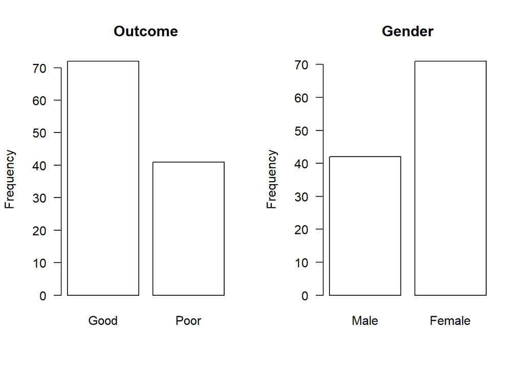

```r
par(mfrow = c(1, 2))

# ── 1. OUTCOME (Devenir neurologique) ─────────────────
barplot(
  table(aSAH$outcome),
  ylab      = "Frequency",
  main      = "Outcome",
  col       = "white",
  border    = "black",
  las       = 1,
  cex.names = 1.0,
  cex.lab   = 1.0
)

# ── 2. GENDER ──────────────────────────────────
barplot(
  table(aSAH$gender),
  ylab      = "Frequency",
  main      = "Gender",
  col       = "white",
  border    = "black",
  las       = 1,
  cex.names = 1.0,
  cex.lab   = 1.0
)
```

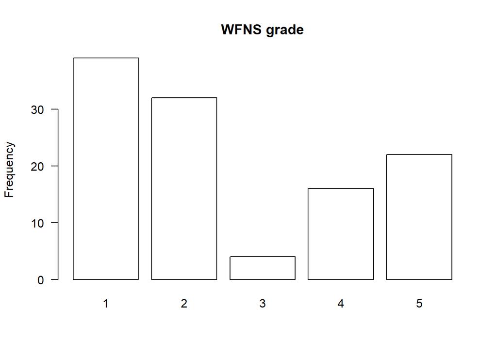

```r
# ── 3. WFNS (grade clinique ordinal) ──────────────────
barplot(
  table(aSAH$wfns),
  ylab      = "Frequency",
  main      = "WFNS grade",
  col       = "white",
  border    = "black",
  las       = 1,
  cex.names = 1.0,
  cex.lab   = 1.0
)
```

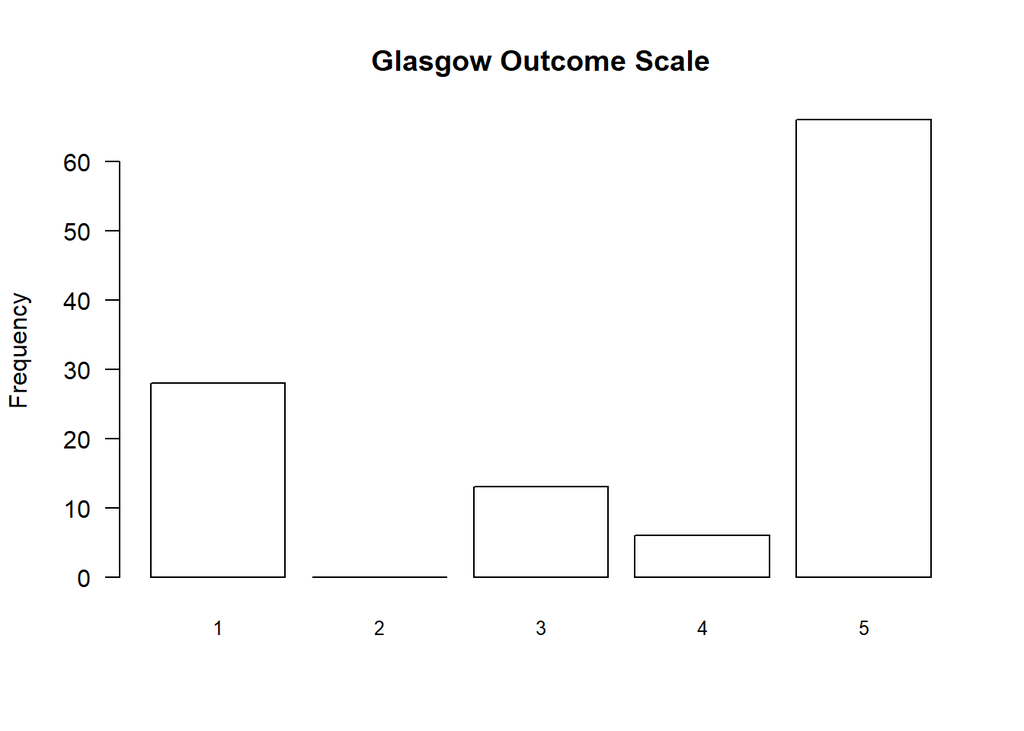

```r
# ── GOS (Glasgow Outcome Scale, 1 à 5) ────────────────
barplot(
  table(aSAH$gos),
  ylab      = "Frequency",
  main      = "Glasgow Outcome Scale",
  col       = "white",
  border    = "black",
  las       = 1,
  cex.names = 0.8,
  cex.lab   = 1.0
)
```

## **Missing data**

```r
tab_NA <- data.frame(
  Variables = names(aSAH),
  n_NA = colSums(is.na(aSAH)),
  percent_NA = round(colMeans(is.na(aSAH)) * 100, 2),
  row.names = NULL )

print(tab_NA)
```

```
##   Variables n_NA percent_NA
## 1      gos6    0          0
## 2   outcome    0          0
## 3    gender    0          0
## 4       age    0          0
## 5      wfns    0          0
## 6     s100b    0          0
## 7      ndka    0          0
```

# **Statistical Modeling**

## **Step 1: ROC curve and identification of the optimal threshold**

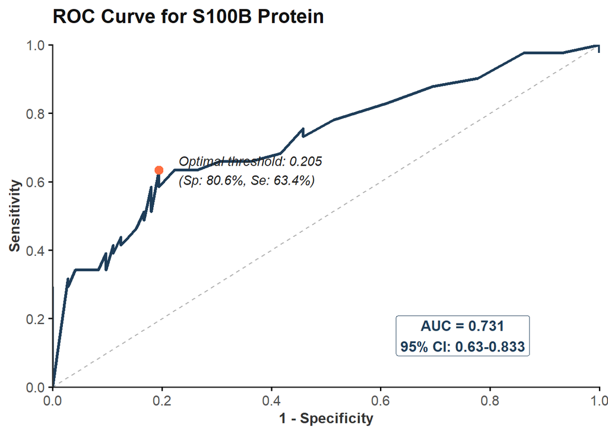

```r
library(pROC)
library(ggplot2)

# 1. Extraction des coordonnées de la courbe pour ggplot
df_roc <- data.frame(
  Sensitivity = roc_biomark$sensitivities,
  Specificity = roc_biomark$specificities
)

# 2. Calcul de l'AUC
auc_valeur <- round(auc(roc_biomark), 3)

ci_valeurs <- round(ci.auc(roc_biomark), 3) # Extrait l'IC 95%

# Création du texte pour le graphique
texte_auc <- paste0("AUC = ", auc_valeur, "\n95% CI: ", ci_valeurs[1], "-", ci_valeurs[3])

# 3. Création du graphique
ggplot(df_roc, aes(x = 1 - Specificity, y = Sensitivity)) +

  # Ligne de référence diagonale (hasard)
  geom_segment(aes(x = 0, y = 0, xend = 1, yend = 1),
               color = "grey70", linetype = "dashed", size = 0.5) +
  # La courbe ROC
  geom_line(color = "#1e3d59", size = 1.2) +
  # Point sur le seuil optimal
  geom_point(aes(x = 0.194, y = 0.634), color = "#ff6e40", size = 3) +

  # Étiquette du seuil
  annotate("text", x = 0.23, y = 0.634,
           label = "Optimal threshold: 0.205\n(Sp: 80.6%, Se: 63.4%)",
           hjust = 0, size = 3.8, fontface = "italic", color = "#222222") +

  #pour l'AUC
  annotate("label", x = 0.75, y = 0.15,
           label = texte_auc,
           size = 4.2, fontface = "bold", fill = "white", color = "#1e3d59", label.size = 0.2) +

  # Ajustement strict des axes entre 0 et 1
  scale_x_continuous(limits = c(0, 1), breaks = seq(0, 1, 0.2), expand = c(0, 0)) +
  scale_y_continuous(limits = c(0, 1), breaks = seq(0, 1, 0.2), expand = c(0, 0)) +

  # Titres et labels
  labs(
    title = "ROC Curve for S100B Protein",
    x = "1 - Specificity",
    y = "Sensitivity"
  ) +

  # Thème minimaliste
  theme_classic(base_size = 14) +
  theme(
    plot.title = element_text(face = "bold", size = 16, color = "#111111", margin = margin(b = 15)),
    axis.title = element_text(face = "bold", size = 12, color = "#333333"),
    axis.text = element_text(color = "#555555"),
    axis.line = element_line(color = "#333333", size = 0.6)

)
```

```r
# Calcul de l'IC à 95% de l'AUC
ci.auc(roc_biomark)
```

```
## 95% CI: 0.6301-0.8326 (DeLong)
```

## **Step 2: Dichotomization of the continuous marker**

Using this threshold, the continuous S100B values were transformed into a binary classification variable. Patients with S100B ≥ 0.205 µg/L were classified as “Positive alert” (high risk of poor outcome), while those below the threshold were classified as “Normal.”

## **Step 3: Cohen’s kappa for agreement analysis**

To assess whether this biomarker-based classification rule agreed with an established clinical severity score, the WFNS grade was dichotomized (WFNS ≥ 3 vs. < 3) into a second binary variable.

Cohen’s kappa was then computed between the two binary classifiers.

```r
# Étape 2 : Transformation du score continu en variable binaire grâce au seuil
aSAH$test_proteine <- ifelse(aSAH$s100b >= seuil_optimal, "Positive alert", "Normal")
```

```r
# Étape 3 : Création d'une deuxième variable binaire à partir du score de gravité WFNS ==> pour kappa STANDARD

# (WFNS va de 1 à 5, on sépare en Faible < 3 vs Fort >= 3)

aSAH$wfns_binaire <- ifelse(as.numeric(aSAH$wfns) >= 3, "Positive alert", "Normal")
```

# **Results**

```r
# Étape 3 : Calcul du Coefficient Kappa

# Mesure l'accord qualitatif entre s100b (dichotomisé par le seuil ROC) et le wfns (dichotomisé)

coef_kappa <- kappa2(aSAH[, c("test_proteine", "wfns_binaire")])

print(coef_kappa)
```

```
##  Cohen's Kappa for 2 Raters (Weights: unweighted)
##
##  Subjects = 113
##    Raters = 2
##     Kappa = 0.694
##
##         z = 7.38
##   p-value = 1.57e-13
```

```r
library(vcd)

# Créer d' la table de contingence
tab <- table(aSAH$test_proteine, aSAH$wfns_binaire)

K <- Kappa(tab)

print(K, CI = TRUE) # Afficher directement avec l'IC
```

```
##             value     ASE     z  Pr(>|z|)  lower  upper
## Unweighted 0.6939 0.07057 9.832 8.157e-23 0.5556 0.8322
## Weighted   0.6939 0.07057 9.832 8.157e-23 0.5556 0.8322
```

# **Conclusion**

This study combined ROC analysis and Cohen’s kappa to evaluate the predictive value of clinical and biological markers in aneurysmal subarachnoid hemorrhage.

Together, these results illustrate that discrimination and agreement are complementary dimensions of predictive validity: a marker may discriminate well without classifying identically to another, and this divergence is precisely what justifies combining markers rather than substituting them.